# Papetiers Report 6

# Introduction

Since performing our last analysis, I have received a new insight into the data. The main reason there is a mismatch between the print run and sales data is that print runs are not available for every edition.

In this notebook, I finally try to get a good grasp on the relationship between print runs, sales and stocktakes in the data. I also try to estimate the ‘wastage’, that is, how much excess paper was required to produce a given edition. It is not clear what the STN did with remaindered stock. Once we understand the wastage, it might be possible to reconstruct the paper requirements for editions whose print runs we do not know.

Moreover, SB has informed me that the STN tended to produce print runs with a standard number of copies, e.g. 250, 300, 500, 750, 1000, 1250, 1500, 2000, 3000, 4000, 5000, 6000, 10000. So in cases where print runs are not available, we may be able to round our estimates to produce a more realistic print run total.

```r
source('init_hidden.R')
```

# Which editions do we have print run and sales data for?

```r
transaction <- mpce %>% fetch_table("stn_transaction") %>%
  left_join(edition, by = "edition_code") %>%
  filter(edition_type %in% stn_edition_types) %>%
  left_join(order, by = 'order_code') %>%
  mutate(date = as.integer(date)) %>%
  select(work_code = work_code.x, -work_code.y, everything())
```

```
NAs introduced by coercion to integer range
```

Let’s get a first rough idea. How many editions do we have print runs for? There are 246 unique STN editions in the transaction data. Of these, 90 have print run data available. A further 115 have assumed print runs.

So only a subset have print-run data. The question is, how complete is the print-run data for these editions, and what proportion of the STN’s total output do they represent?

| work_code | balance | actually_printed | assumed_printed | other_in | sold | stocktakes | full_book_title |
| --- | --- | --- | --- | --- | --- | --- | --- |
| spbk0000497 | -20816 | 1000 | 0 | 1950 | -23766 | 2500; 2188; 1507; 5462; 4442; 5154; 4126; 8004; 9952; 9952; 19 | Descriptions des arts et métiers, faites ou approuvées par Messieurs de l'Académie royale des sciences de Paris |
| spbk0002756 | -14413 | 15000 | 0 | 30 | -29443 | 15500; 1260; 1100 | Histoire philosophique et politique des établissements et du commerce des Européens dans les deux Indes |
| spbk0003309 | -4900 | 3000 | 0 | 417 | -8317 | 2392; 1894; 6; 983; 756; 142; 13 | Cours abrégé de géographie historique, ancienne & moderne, et de sphère: par demandes et réponses. Troisième edition |
| spbk0003731 | -3695 | 4487 | 0 | 7050 | -15232 | 28; 396; 80 | Bibliothèque philosophique du législateur, du politique, du jurisconsulte ou Choix des meilleurs discours, dissertations, essais, fragmens, composés sur la législation criminelle par les plus célèbres… |
| spbk0000021 | -1633 | 4000 | 0 | 1183 | -6816 | 3700; 1113; 2432; 5; 5; 74; 1780; 1600; 20; 20; 1437; 10; 518; 122; 29; 7; 1; 384; 1; 77; 122; 8; 2; 131; 54 | [Abrégé de l'histoire sainte et du catéchisme] |
| spbk0002981 | -1612 | 2000 | 0 | 478 | -4090 | 1562; 42; 158 | Système de la nature ou Des loix du monde physique & du monde moral |
| spbk0002332 | -1240 | 2250 | 0 | 952 | -4442 | 787; 781; 167; 64 | Théatre à l'usage des jeunes personnes |
| spbk0003563 | -1162 | 750 | 0 | 127 | -2039 | 37; 28; 642; 2; 1768; 1134; 135 | Discours politiques, historiques et critiques sur quelques gouvernemens de l'Europe |
| spbk0002948 | -739 | 3000 | 0 | 147 | -3886 | 1116; 1028; 1038; 793; 793; 619; 480; 13; 354; 3719; 957; 721 | Géographie élémentaire. Troisième édition |
| spbk0003755 | -576 | 2060 | 0 | 58 | -2694 | 229; 9; 4; 1672; 174; 344; 766; 604; 92; 550; 18 | Thévenon (le), ou Les journées de la montagne |

[output cut: 170 more lines]

Let’s look at one of these editions, and see if we can work out what is going on. One edition that has a big mismatch between the amount printed and the number sold is bk0001961, *Bibliothèque philosophique du législateur, du politique, du jurisconsulte ou Choix des meilleurs discours, dissertations, essais, fragmens, composés sur la législation criminelle par les plus célèbres écrivains, en françois, anglois, italien, allemand, espagnol, &c. pour parvenir à la réforme des loix pénales dans tous les pays*.

[output not shown]

[output cut: 89 more lines]

Some of the books clearly have quite complete data. Consider bk0000875, Journal et anecdotes intéressantes du voyage de Monsieur le comte de Falckenstein.

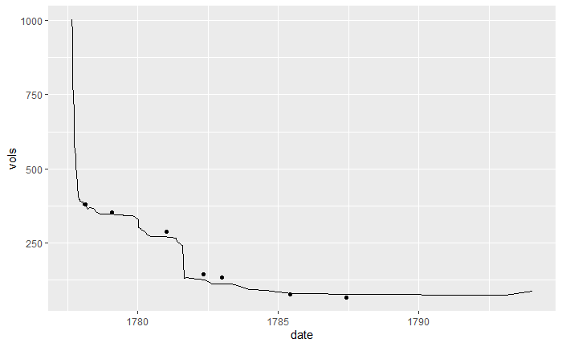

# Constructing a good sample

How can we find all the books in the data like bk0000875, which have consistent printing and sales data?

Some possibilities: * filter out all books whose in and out transactions differ by more than 10% * filter out all books whose cumulative transaction totals drop below 0 at any point * just focus on the manuscripts that are known to be most accurate